# Take-home Exercise 5

Visualising and Analysing Geographic and Movement Data

Raveena Chakrapani https://www.linkedin.com/in/raveena-chakrapani-444a60174/ (School Of Computing and Information Systems, Singapore Management University)https://scis.smu.edu.sg/master-it-business  
2022-05-29

# Overview

The task of this Take-home exercise is to reveal the following by appropriate visualization techniques

- Social areas of the city of Engagement, Ohio USA.
- Visualising and analysing locations with traffic bottleneck of the city of Engagement, Ohio USA.

# Getting Started

### Installing and loading the required libraries

Before we get started, it is important for us to ensure that the required R packages have been installed. If yes, we will load the R pacakges. If they have yet to be installed, we will install the R packages and load them onto R environment.

The code chunk below is used to install and load the required packages onto RStudio.

```r
packages = c('tidyverse','sf','tmap','data.table','knitr','sp')
for(p in packages){
  if(!require(p, character.only = T)){
    install.packages(p)
  }
  library(p, character.only = T)
}
```

### Importing data

The code chunk below imports all the required files from the data folder into R by using [`read_csv()`](https://readr.tidyverse.org/reference/read_delim.html) of [**readr**](https://readr.tidyverse.org/index.html) and save it as an tibble data frame called *data*

```r
# read csv file
travel <- read_csv("data/TravelJournal.csv")
schools <- read_sf("data/wkt//Schools.csv",
                   options = "GEOM_POSSIBLE_NAMES=location")
apartments <- read_sf("data/wkt/Apartments.csv",
                   options = "GEOM_POSSIBLE_NAMES=location")
buildings <- read_sf("data/wkt/Buildings.csv",
                   options = "GEOM_POSSIBLE_NAMES=location")
pubs <- read_sf("data/wkt/Pubs.csv",
                   options = "GEOM_POSSIBLE_NAMES=location")
restaurants <- read_sf("data/wkt/Restaurants.csv",
                   options = "GEOM_POSSIBLE_NAMES=location")
employers <- read_sf("data/wkt/Employers.csv",
                   options = "GEOM_POSSIBLE_NAMES=location")
```

```r
apartments <- apartments %>%
  mutate(across(rentalCost, as.integer),
  across(maxOccupancy, as.integer),
  across(numberOfRooms, as.integer))

  apartments$rentalCost <- cut(apartments$rentalCost , breaks = c(347,531,713,876,1040,1250,1601),labels = c('348-531','532-713','714-876','877-1040','1041-1250','1251-1601'),include.lowest=TRUE)
```

Let’s visualise the restaurants and pubs with different no. of occupancies

```r
buildings <- buildings %>%
  mutate(across(maxOccupancy, as.integer))

  buildings$maxOccupancy <- cut(buildings$maxOccupancy , breaks = c(1,25,50,75,100,420),labels = c('2-25','26-50','51-75','76-100','101-420'),include.lowest=TRUE)

restaurants <- restaurants %>%
  mutate(across(maxOccupancy, as.integer))
pubs <- pubs %>%
  mutate(across(maxOccupancy, as.integer))
```

```r
tmap_mode("view")
tm_shape(buildings)+
tm_polygons(col = "maxOccupancy",
           size = 1,
           border.col = "black",
           border.lwd = 1,
           legend.show = FALSE)+

tm_shape(pubs)+
tm_markers(col = "yellow",
           shape= marker_icon(),
           size = "maxOccupancy",
           border.col = "black",
           border.lwd = 1)+

tm_shape(restaurants)+
tm_bubbles(col = "blue",
           shape= marker_icon(),
           size = "maxOccupancy",
           border.col = "black",
           border.lwd = 2)
```

[interactive chart not shown]

### Insights

When we zoom the graph, It shows that restaurants 447,898, 896 have most no. of occupancy and pubs 892, 444, 893 have higher occupancy compared to others.

Let us look at the apartments in the city with respect to no. of rooms

```r
apartments$numberOfRooms <- as.numeric(apartments$numberOfRooms)
tm_shape(apartments)+
tm_bubbles(col = "yellow",
           size = "numberOfRooms",
           border.lwd = 0.5) +
  tm_facets(by= "numberOfRooms",
            sync = TRUE)
```

[interactive chart not shown]

### Insights

The above graph shows that the apartments in the city with different no. of rooms are almos the same.

Now, let’s see what is the duration which the participant spends in each pub or restaurant of the city.

```r
travel_tidy <- travel %>%
  mutate(travel_duration = difftime(travelEndTime,travelStartTime, units="mins"),
  time_spent = difftime(checkOutTime, checkInTime,units = "mins"),
  amount_spent = startingBalance - endingBalance ) %>%
  dplyr::select(participantId,travelStartLocationId,travelEndLocationId,travel_duration,time_spent,amount_spent,purpose)
kable(head(travel_tidy))
```

[output not shown]

```r
restaurant_filt <- travel_tidy %>%
  filter(purpose== "Coming Back From Restaurant")
restaurant_merge <- merge(restaurant_filt, restaurants, by.x="travelStartLocationId",
      by.y="restaurantId",
      all.x=TRUE)
rest_grp <- restaurant_merge %>%
  group_by(travelStartLocationId) %>%
  dplyr::summarise(tot_time = sum(time_spent))

rest_grp_merge <- merge(rest_grp,restaurants,by.x="travelStartLocationId",
      by.y="restaurantId",
      all.x=TRUE)
# rest_grp_merge
# fwrite(rest_grp_merge,
#      file= "data/rest_grp_merge.csv",
#       sep = ",")
```

```r
pubs_filt <- travel_tidy %>%
  filter(purpose== "Recreation (Social Gathering)")
pub_merge <- merge(pubs_filt, pubs, by.x="travelEndLocationId",
      by.y="pubId",
      all.x=TRUE)
pub_grp <- pub_merge %>%
  group_by(travelEndLocationId) %>%
  dplyr::summarise(tot_time = sum(time_spent))
pub_grp_merge <- merge(pub_grp,pubs,by.x="travelEndLocationId",
      by.y="pubId",
      all.x=TRUE)
#pub_grp_merge
# fwrite(pub_grp_merge,
#      file= "data/pub_grp_merge.csv",
#       sep = ",")
```

```r
rest_data <- read_csv("data/rest_grp_merge.csv")
rest_data_sf <- st_as_sf(
  rest_data,
  coords = c("XCOORD",
             "YCOORD"),
             crs= 7285)

pub_data <- read_csv("data/pub_grp_merge.csv")
pub_data_sf <- st_as_sf(
  pub_data,
  coords = c("XCOORD",
             "YCOORD"),
             crs= 7285)
```

```r
tmap_mode("view")
tm_shape(rest_data_sf)+
tm_markers(shape=marker_icon(),
           col = "blue",
           size = "tot_time",
           border.col = "black",
           border.lwd = 0.5)+
tm_shape(pub_data_sf)+
tm_markers(shape=marker_icon(),
           col = "yellow",
           size = "tot_time",
           border.col = "black",
           border.lwd = 1)
```

[interactive chart not shown]

### Insights

It is observed from the graph that participants spend more amount of time in these pubs (1342, 1799) and in these restaurants (896, 445)

### Movement Analysis

Let’s look at the movement pattern of the participants in the city.

```r
logs_selected <- read_rds("data/logs_selected.rds")
buildings <- read_sf("data/wkt/Buildings.csv",
                   options = "GEOM_POSSIBLE_NAMES=location")
```

Lets filter out the peak hours and try to visualize what are the areas where traffic is more

```r
logs_path_peak <-logs_path %>%
  mutate(time=format(m,"%H:%M:%S")) %>%
  filter(time >= "18:00:00" & time <= "23:30:00") %>%
  filter(participantId >= 0 & participantId <= 50 )
```

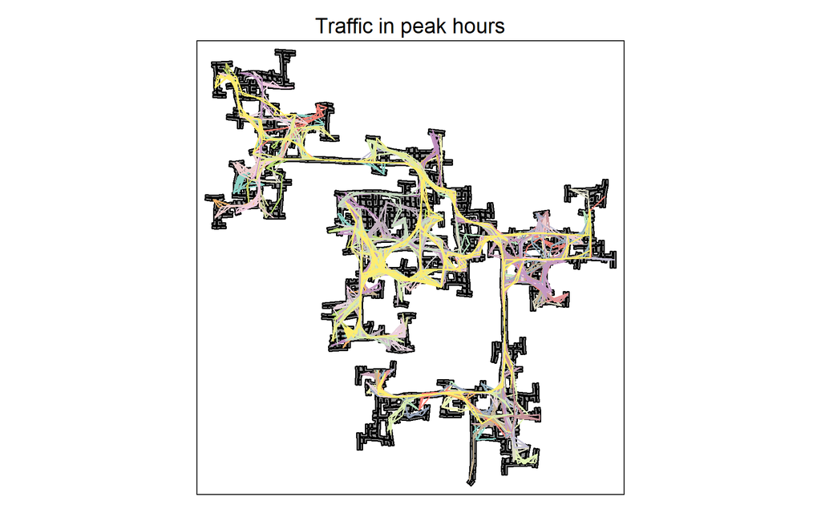

```r
tmap_mode("plot")
tm_shape(buildings)+
tm_polygons(col = "grey60",
size = 1,
border.col = "black",
border.lwd = 1) +
tm_shape(logs_path_peak) +
tm_lines(col = "participantId") +
tm_layout(main.title = "Traffic in peak hours",
            main.title.position = "center",
            main.title.size = 1,
            legend.show = FALSE)
```

### Insights

- The above graph shows that the center part of the city is highly congested during evening peak hours as the density of line is thick.